# Marker union rarefaction

How the union of donor sites grows with donors: a demographic model of teosinte, the simulations that would complete it, and the curves fitted to the six donors of the eight-donor chr10 test whose families have balanced tissue pools (2026-10-11), and the 24 such families of the 42 mexicana donors (2026-10-16)

Author

Fausto Rodríguez-Zapata

Published

October 16, 2026

The marker union is every site found in at least one donor (math supplement, Section 5.1). Its size sets the cost of the union counts, of gap filling and of every per-line table, so it is projected before a run over all donors. This notebook (i) states what is known about the donors’ populations and the union it implies, (ii) writes down the simulations that would turn that into a predicted curve, (iii) fits empirical curves to the data we have, and (iv) reads the fits against the demographic picture, including what to expect from other taxa. The simulations are not run: they are written here to be run once the union over all samples exists. The math supplement’s Section 5.6 summarises sections 3-4.

**NoteIn short**

- **Demography (Chen et al. 2022).** Mexicana’s effective size fell about threefold between ~30 and ~5 thousand years ago (MSMC2), and mexicana accessions carry about **6x** the private variation a neutral equilibrium predicts. Mexicana races are topographically isolated populations (Sánchez-González et al. 2018). Expected: real alleles saturate within a population, each new population adds a block of private alleles, and false alleles add a constant number per donor.
- **Simulations proposed** (section 2): the expected site frequency spectrum of the donors under (S1) mexicana’s Ne history, (S2) races as demes, (S3) the Zea species tree with ZEAL’s donor composition; Eq. 1 turns each into a union curve.
- **Empirical fits** (six mexicana donors, four races, families with balanced tissue pools; two families off the curve shown apart): Michaelis-Menten ($U_\infty \approx 474$ thousand sites on chr10), Watterson, and Watterson with false alleles ($\varepsilon_f \approx 13$ thousand per donor): 245, 225 and 263 thousand sites at 10 donors. The false-allele term’s linear growth is what sets the last apart (section 3.7). The five-donor fits overshot the sixth donor by 5-11 % (section 3.8).
- **A new race** (Zx.0160_P2, Chalco) adds a larger share of its sites than a race-mate but fewer sites, as its discovery finds fewer tier-A sites (section 3.2).
- **Reading.** Chen’s numbers are genome-wide; scaled to our low-copy ranges (section 4), neither false calls (read-based precision 0.97, supplement Section 5.5) nor Chen’s private SNPs account for most of the private term $\varepsilon_f$. It is about the size of the sites where read and assembly alignment disagree; what it holds is untested. The discovery sensitivity is not determined from Chen. Other taxa: Zea as a whole carries 2.3x mexicana’s SNPs in Chen’s panel, an upper bound for the union’s growth when ZEAL’s parviglumis and other donors are added.

## 1. A demographic model of the donors

### 1.1 Who the donors are

ZEAL has 96 teosinte donors (`meta/samples.csv`). Mexicana races from the passport table (`meta/accessions.csv`, J2Teo); teosinte races are “geographical populations spatially isolated by the topography in Mexico and Central America” (Sánchez-González et al. 2018).

| taxon | donors | mexicana donors by race |
| --- | --- | --- |
| mexicana | 43 | Mesa Central 21, Chalco 14, Durango 5, Nobogame 3 |
| parviglumis | 40 |  |
| diploperennis | 6 |  |
| luxurians | 5 |  |
| huehuetenangensis | 2 |  |

### 1.2 What Chen et al. (2022) measured

Chen et al. resequenced 237 teosinte accessions (22x) with 507 maize lines. Their Supplementary Table 2 (diversity map), Supplementary Table 4 (BPP demography), Fig. 2a (F<sub>ST</sub>) and Supplementary Fig. 3 (MSMC2 Ne through time) give:

| taxon | accessions | SNPs (M) | taxon-specific SNPs (M) | taxon-specific, downsampled (M) | π per bp | F_ST with mexicana | F_ST with maize |
| --- | --- | --- | --- | --- | --- | --- | --- |
| mexicana | 81 | 31.32 | 4.26 | 1.82 | 0.00804 |  | 0.158 |
| parviglumis | 70 | 41.51 | 5.97 | 1.14 | 0.00847 | 0.068 | 0.101 |
| diploperennis | 20 | 11.66 | 1.13 | 1.06 | 0.00629 | 0.277 | 0.356 |
| perennis | 19 | 15.29 | 1.70 | 1.70 | 0.01038 | 0.277 | 0.354 |
| luxurians | 14 | 9.04 | 0.48 | 0.58 | 0.00592 | 0.290 | 0.364 |
| nicaraguensis | 14 | 7.41 | 0.37 | 0.41 | 0.00543 | 0.270 | 0.342 |
| huehuetenangensis | 5 | 7.99 | 0.64 | 1.00 | 0.00572 | 0.248 | 0.330 |

F<sub>ST</sub> with maize is Chen’s cultivated panel (507 inbreds; B73’s subspecies): parviglumis and mexicana are closest to maize (0.101, 0.158), the other taxa 0.33-0.36, so B73 is the outgroup of Eq. 1 for every donor, nearer to some taxa than others. All Zea together (744 genomes, maize included): 70.73 M SNPs, 16.90 M taxon-specific. Mexicana’s chr10 windows (Fig. 2b data): mean $\pi$ = 0.00903. SNPs specific to one accession (Fig. 2d data): mexicana median 402,200 per accession (166,559-518,710), parviglumis 322,355.

**Ne through time** (Supplementary Fig. 3, MSMC2; values read off the figure, approximate):

| Time before present | mexicana | parviglumis |
| --- | --- | --- |
| ~30 ky | ~82,000 | ~86,000 |
| ~20 ky | ~77,000 | ~86,000 |
| ~12 ky | ~60,000 | ~86,000 |
| ~8 ky | ~44,000 | ~76,000 |
| ~5 ky to now | ~27,000 | ~62,000, then ~49,000 since ~4 ky |

The perennial and Central American taxa (diploperennis, luxurians, nicaraguensis, huehuetenangensis, perennis) decline from 35-60 thousand around 50-100 ky to 10-25 thousand around 8-10 ky, then rise again (diploperennis and luxurians to ~42-47 thousand). BPP divergence times (Supplementary Table 4, years): the (maize, parviglumis, mexicana) clade 30,467; with huehuetenangensis 67,800; with diploperennis and perennis 121,533; the Zea crown 124,233; Zea-Tripsacum 653,733. BPP’s Ne for mexicana is 171,508 (95 % HPD 146,817-197,008), on a different scale from MSMC2’s; only the shape of the MSMC2 history is used.

### 1.3 The union under a coalescent

Take B73 as the outgroup: a union site is a position where at least one donor carries an allele different from B73. Under infinite sites, such alleles arise (a) on the B73 lineage or on the donors’ lineage before their common ancestor, carried by every donor (the fixed differences, $C$ of them), or (b) on the donors’ genealogy, carried by $k$ of the $n$ donors. Each donor finds a carried allele with probability $\eta$ (discovery sensitivity), and calls $\varepsilon_f$ false alleles of its own. Then

$$\mathbb{E}[U_n] = C\,\big[1 - (1 - \eta)^n\big] \;+\; \theta \sum_{k=1}^{n-1} \xi_k(n)\, \big[1 - (1
- \eta)^k\big] \;+\; \varepsilon_f\, n \tag{1}$$

with $\theta = 4 N_e \mu L$ over the sites considered and $\xi_k(n)$ the expected site frequency spectrum of $n$ donors in units of $\theta$ (the expected length of the genealogy’s branches that subtend exactly $k$ donors, scaled). **Demography and structure enter only through $\xi_k(n)$.** For one population at constant size (Wright-Fisher equilibrium), $\xi_k(n) = 1/k$; with $\eta = 1$ and $\varepsilon_f = 0$, Eq. 1 is Watterson’s (1975)

$$\mathbb{E}[U_n] = C + \theta \sum_{k=1}^{n-1} \frac{1}{k} = C + \theta H_{n-1} \tag{2}$$

How $\xi_k(n)$ departs from $1/k$:

- **A recent contraction** (mexicana, threefold over the last ~30 ky, recent relative to the current $2 N_e \approx 54$ ky): fewer singletons and low-frequency alleles than $1/k$, more at intermediate frequencies; the union saturates faster than $H_{n-1}$.
- **Structure** (isolated races, low migration): donors from one deme share recent ancestry; a donor from a new deme adds the long branches of that deme, a block of private alleles. The union grows by steps as demes are added.
- **Several taxa**: the same, at the scale of the species tree (Section 5).

### 1.4 The equilibrium baseline

zealgt-old notebook 01 (2026-09-26) used the large-population version of Eq. 2: site frequencies $p$ in the population with the neutral spectrum $g(p) \propto 1/p$ (a flat spectrum as the contrast), a carried allele found with probability $\eta$, no fixed differences and no false alleles:

$$\mathbb{E}[U_n] = S \sum_{p} g(p) \left[ 1 - (1 - \eta p)^n \right], \qquad \hat U_n =
U_2^{\mathrm{obs}} \, \frac{\mathbb{E}[U_n]}{\mathbb{E}[U_2]} \tag{3}$$

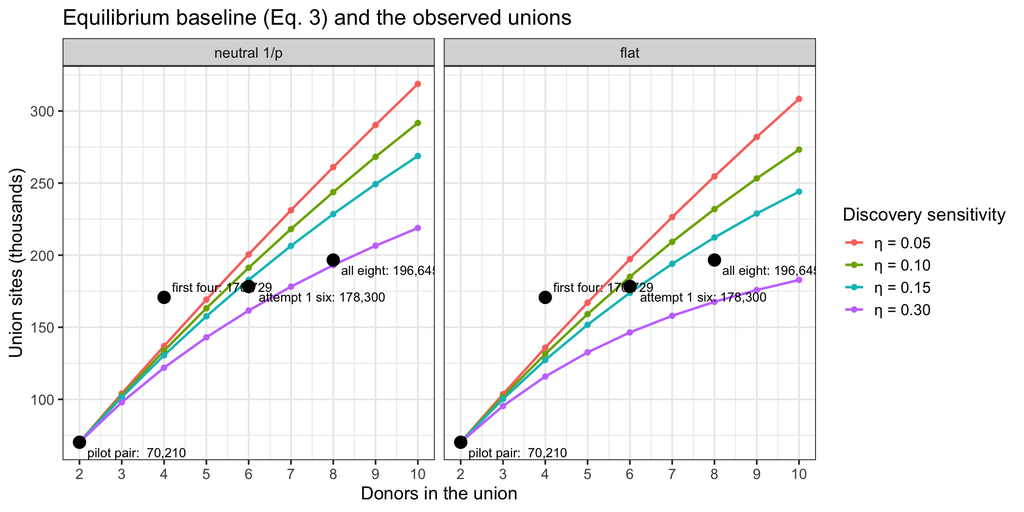

At 4 donors Eq. 3 gives 1.74-1.95x (neutral) the 2-donor union; the first four donors gave 2.43x. The pipeline unions at 6 and 8 donors include the two donors off the curve (section 3.1). The equilibrium baseline has no private term: neither the false alleles nor the demes of section 1.3.

## 2. Proposed simulations (not run)

Each simulation produces $\xi_k(n)$ for the donor sets of interest; Eq. 1 turns it into a union curve with $\theta$ from Chen’s $\pi$, $\eta$ and $\varepsilon_f$ from our data (section 4), and $C$ from the fixed differences (or fitted). Tool: msprime with a demes model (demography as a YAML file), infinite sites, no recombination needed for expectations (or chr10’s recombination map to get the variance along the chromosome); about $10^4$ replicate genealogies per donor set.

|  | Model | Parameters (source) | Donor sampling | Output |
| --- | --- | --- | --- | --- |
| **S0** | one population, constant $N_e$ | none | $n$ haplotypes | $\xi_k(n) = 1/k$: checks the pipeline against Eq. 2 |
| **S1** | mexicana, one population, piecewise $N_e(t)$ | Supplementary Fig. 3 steps (section 1.2; digitise the figure for exact values); generation time 1 year | $n = 1, \dots, 43$ | the contraction’s effect on $\xi_k(n)$ and the union’s saturation |
| **S2** | mexicana races as demes (Mesa Central, Chalco, Durango, Nobogame), each with S1’s history, symmetric migration $m$ | $m$ swept so that within-race vs between-race diversity matches Chen’s accession-specific SNPs (6x neutral, section 4) and mexicana’s K = 2 | ZEAL’s mexicana donors: 21 / 14 / 5 / 3 by race, added in random order and race by race | the step a new race adds; the 43-donor mexicana union |
| **S3** | the Zea species tree | BPP divergence times and Ne (Supplementary Table 4), MSMC2 histories per taxon, introgression ignored at first | ZEAL’s 96 donors (43 / 40 / 6 / 5 / 2 by taxon), in random order and taxon by taxon | the union over all donors, and the block each taxon adds |

Calibration targets for S1-S3 (Chen’s panel, 22x individual genomes): per-taxon SNP counts, taxon-specific and downsampled taxon-specific SNPs, $\pi$, F<sub>ST</sub> (section 1.2). Chen’s samples are not ZEAL’s donors (none of the six donors’ collection numbers is among them), so the simulations use Chen for the populations and ZEAL only for the sampling. The targets should be Chen’s counts **within our low-copy ranges** (their SNP positions intersected with `lowcopy_chr1-10.bed`), not the genome-wide totals of section 1.2: the share of their SNPs in our ranges is unknown (section 4).

## 3. Empirical curves fitted to the data

### 3.1 The data

Eight mexicana donors from four races, chr10, tier-A sites (step 4 of variant discovery): the four Durango and Nobogame donors of the first test, two Mesa Central and two Chalco donors (union test, `docs/runs/genotype_union_6donors_races_chr10.md`, attempts 1 and 3). Own sites from the tier-A VCFs; unions from `BIALLELIC_UNION` (GENOTYPE runs: 2 donors job 1111642, 4 donors job 1134902, 6 donors attempt 1, 8 donors job 1152382). The **sharing pattern** of a union site is which donors’ own sites include it, $z \in \{0, 1\}^8$ (job 1152598, `union_rarefaction/patterns_8donors.tsv`; 255 patterns summing to the eight-donor union). The Durango donors were collected about 2 km apart (Nombre de Dios, Durango), the Nobogame donors about 3 km apart (Guadalupe y Calvo, Chihuahua).

A donor enters the curve if its family’s lines show what the donor carries (`docs/decisions.md`, 2026-10-11). Checked on the lines’ RTIGER calls at the union sites gap filling called ALT for the donor:

1. at most 4 donor segments per line;
2. segment dosage in the bands of good families: reads in REF segments <= 3 % ALT, in HET segments 30-55 %, in ALT segments >= 75 %;
3. the donor segments of the lines passing 1-2 cover >= 90 % of chr10.

Six donors pass. **Zx.0090_P2** covers 24 % of chr10, below the 5th percentile (46 %) of what its pedigree predicts (1000 families simulated on its `meta/registry.csv` tree; the tail probability not computed): unusually low, worth a check of the family against the registry. The simulation counts a position covered when any of a line’s six plants carries a donor allele, which RTIGER may call REF at 1/12 dosage, so observed coverage runs low against it for every family; the six families on the curve still reach 93-100 %. **Zx.0470_P2** covers 73 %, within what its small pedigree predicts (4 BC1 and 7 BC2 plants; median 90 %): its lines carry too little of the donor to confirm it. Both also lose two thirds of their sites to the witness veto. The curve and the fits below use the **six donors on the curve**; the other two are shown separately (section 3.2).

| donor | race | own tier-A sites | status |
| --- | --- | --- | --- |
| Zx.0540_P3 | Durango | 32,750 | on the curve |
| Zx.0570_P2 | Nobogame | 48,251 | on the curve |
| Zx.0550_P4 | Durango | 85,952 | on the curve |
| Zx.0580_P2 | Nobogame | 82,601 | on the curve |
| Zx.0500_P2 | Mesa Central | 9,060 | on the curve |
| Zx.0090_P2 | Chalco | 7,482 | off the curve |
| Zx.0470_P2 | Mesa Central | 16,283 | off the curve |
| Zx.0160_P2 | Chalco | 19,767 | on the curve |

| union (pipeline) | donors | union sites |
| --- | --- | --- |
| pilot pair | 2 | 70,210 |
| first four | 4 | 170,729 |
| attempt 1 six | 6 | 178,300 |
| all eight | 8 | 196,645 |

| pattern z, Zx.0540_P3 Zx.0570_P2 Zx.0550_P4 Zx.0580_P2 Zx.0500_P2 Zx.0160_P2 | union sites |
| --- | --- |
| 001000 | 43,220 |
| 000100 | 40,488 |
| 010000 | 16,925 |
| 001100 | 12,880 |
| 000001 | 10,587 |
| 100000 | 9,044 |
| 010100 | 7,351 |
| 011100 | 5,114 |
| 011000 | 4,805 |
| 101000 | 4,784 |
| 000010 | 3,893 |
| 111100 | 2,975 |
| 101100 | 2,951 |
| 100100 | 2,504 |
| 111000 | 1,792 |
| 110100 | 1,713 |
| 110000 | 1,674 |
| 001001 | 1,095 |
| 000101 | 916 |
| 010001 | 634 |
| 111101 | 618 |
| 001101 | 599 |
| 100001 | 533 |
| 001010 | 530 |
| 010101 | 494 |
| 011101 | 476 |
| 101001 | 449 |
| 000110 | 439 |
| 101101 | 389 |
| 111001 | 348 |
| 000011 | 338 |
| 011001 | 335 |
| 100010 | 303 |
| 010010 | 288 |
| 111110 | 269 |
| 001110 | 254 |
| 110001 | 246 |
| 011110 | 210 |
| 010110 | 209 |
| 101010 | 196 |
| 110101 | 190 |
| 101110 | 187 |
| 100101 | 182 |
| 111010 | 181 |
| 111111 | 179 |
| 011010 | 163 |
| 110110 | 139 |
| 110010 | 118 |
| 100011 | 97 |
| 111011 | 96 |
| 010011 | 95 |
| 100110 | 95 |
| 101011 | 91 |
| 001011 | 88 |
| 011111 | 81 |
| 000111 | 79 |
| 110011 | 64 |
| 010111 | 60 |
| 101111 | 56 |
| 011011 | 55 |
| 001111 | 50 |
| 110111 | 39 |
| 100111 | 26 |

### 3.2 The rarefaction curve

As in species-richness rarefaction, donors are the samples and sites the species. The rarefaction curve is the mean union over every set of $n$ of the $N$ donors, computed exactly from the sharing patterns:

$$\bar U_n = \binom{N}{n}^{-1} \sum_{|D| = n} \; \sum_{z} N_z \, \mathbb{1}\Big[\max_{d \in D} z_d =
1\Big], \qquad n = 1, \dots, N \tag{4}$$

| donors | curve six | curve six + Zx.0470_P2 | all eight |
| --- | --- | --- | --- |
| 1 | 46,124 | 41,847 | 37,544 |
| 2 | 83,462 | 76,658 | 69,438 |
| 3 | 114,622 | 106,309 | 97,064 |
| 4 | 141,288 | 132,058 | 121,364 |
| 5 | 164,586 | 154,792 | 143,022 |
| 6 | 185,279 | 175,146 | 162,547 |
| 7 |  | 193,582 | 180,323 |
| 8 |  |  | 196,645 |

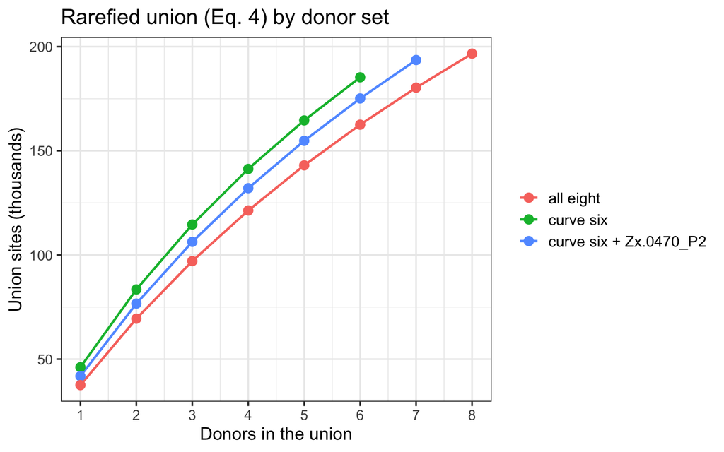

| union | sites | added to the curve six |
| --- | --- | --- |
| curve six | 185,279 |  |
| + Zx.0470_P2 | 193,582 | 8,303 |
| + Zx.0090_P2 | 188,457 | 3,178 |
| + Zx.0470_P2 and Zx.0090_P2 | 196,645 | 11,366 |

Each donor off the curve adds 3,178-8,303 sites, a few per cent of the union: they find few sites (7-16 thousand tier-A) and share most of them with the six. Zx.0470_P2 lowers the rarefied curve at every $n$ for the same reason.

**A new race against a race-mate.** Zx.0160_P2 (Chalco) has 10,925 union sites that none of the four Durango and Nobogame donors has, 0.56 of its own; each Durango or Nobogame donor against the other three has 10-45 thousand such sites, 0.31-0.53 of its own (run plan, attempt 3). The new race adds a larger share but fewer sites, because its discovery finds fewer tier-A sites (19,767 against 33-86 thousand): discovery depth, not race, sets most of what a donor adds.

### 3.3 Michaelis-Menten

Species accumulation curves are routinely fitted with (supplement Eq. 21; Soberón and Llorente 1993)

$$\bar U_n = \frac{U_\infty\, n}{K + n} \tag{5}$$

the asymptote $U_\infty$ and the number of donors $K$ that reach half of it. Fitted: $U_\infty$ = 474,000, $K$ = 9.4, RMSE 328 sites. If each site is found by each donor with rate $k_s$ and $k_s$ is gamma-distributed across sites (shape $\alpha$, scale $1/K$) (supplement Eq. 22),

$$\bar U_n = U_\infty \left[ 1 - \left( 1 + \frac{n}{K} \right)^{-\alpha} \right] \tag{6}$$

which is Eq. 5 at $\alpha = 1$, the negative exponential as $\alpha \to \infty$, logarithmic growth (Fisher’s log-series) as $\alpha \to 0$ and power growth for $\alpha < 0$. Since $k_s \approx \eta p_s$, $\alpha$ is the shape of the spectrum near $p = 0$: the neutral $1/p$ is $\alpha \to 0$; Michaelis-Menten is a spectrum with fewer rare alleles than neutral and a finite pool of sites.

### 3.4 Watterson

Eq. 1 at equilibrium, $\xi_k(n) = 1/k$, with $\eta$ absorbed into the fitted constants and no private term: the union grows with the harmonic number, like $\ln n$, and has no ceiling.

$$\bar U_n = c + \theta_\eta H_n \tag{7}$$

Fitted: $c$ = -55,942, $\theta_\eta$ = 96,055, RMSE 4,710 sites. $c$ is negative, which Eq. 2 does not allow (fixed differences cannot be fewer than none), and the residuals follow a pattern, not noise ( 6,011, -4,679, -5,537, -2,884, 1,202, 5,886 for $n = 1, \dots, 6$: above, below, below, below, above, above): the curve bends too early.

### 3.5 Watterson with false alleles

Eq. 7 plus the private term of Eq. 1 (supplement Eq. 23):

$$\bar U_n = c + \theta_\eta H_n + \varepsilon_f\, n \tag{8}$$

Fitted: $c$ = -18,312, $\theta_\eta$ = 50,715, $\varepsilon_f$ = 13,322 per donor, RMSE 587 sites. $c$ is still negative; three parameters on six points leave three degrees of freedom, so this is a consistency check.

### 3.6 The three curves together

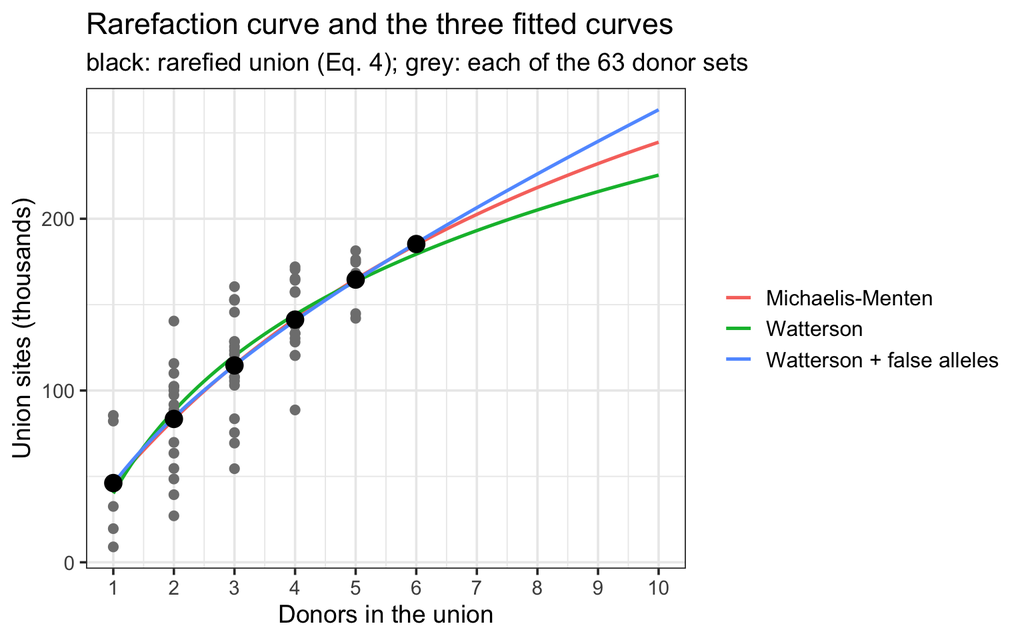

| model | fitted parameters | RMSE (sites) | predicted at 10 donors |
| --- | --- | --- | --- |
| Michaelis-Menten | U_∞ = 474000, K = 9.39 | 328 | 244,577 |
| Watterson + false alleles | c = -18300, θ_η = 50700, ε_f = 13300 | 587 | 263,451 |
| Watterson | c = -55900, θ_η = 96100 | 4,710 | 225,400 |

| donors | Michaelis-Menten | Watterson | Watterson + false alleles | of which c + θ_η H_n | of which ε_f n |
| --- | --- | --- | --- | --- | --- |
| 5 | 164,781 | 163,384 | 164,097 | 97,487 | 66,610 |
| 6 | 184,888 | 179,393 | 185,872 | 105,940 | 79,932 |
| 10 | 244,577 | 225,400 | 263,451 | 130,231 | 133,220 |
| 20 | 322,716 | 289,639 | 430,587 | 164,148 | 266,439 |
| 43 | 389,231 | 361,898 | 775,143 | 202,299 | 572,845 |

### 3.7 Why Watterson with false alleles diverges from the other curves

The curves agree on the six points and part beyond them, into two groups: those whose growth fades (logarithmic, negative exponential, Watterson, Michaelis-Menten: 216-245 thousand sites at 10 donors, Appendix A) and those with a term that never fades (Watterson with false alleles and the power curve: 263-274 thousand).

1. **The data grow faster than a logarithm and slower than a line.** The free power curve puts the exponent at 0.74. Watterson (Eq. 7) can only grow like $\ln n$; its residuals run above, below, then above (section 3.4), so it bends too early and falls short beyond the data. That is also why it needs a negative $c$.
2. **The $\varepsilon_f n$ term takes the excess growth.** With it, $\theta_\eta$ drops from 96,055 to 50,715, $\varepsilon_f$ takes 13,322 per donor, and the RMSE falls from 4,710 to 587 sites. Beyond the data the linear term keeps adding $\varepsilon_f$ per donor while $\theta_\eta H_n$ flattens; from about 10 donors $\varepsilon_f n$ is the larger part (table above).
3. **The split between $\theta_\eta$ and $\varepsilon_f$ is poorly determined.** Their estimates are correlated at -0.98 (standard errors 3,362 and 967): many combinations fit the six points almost equally and differ widely at 10 donors and beyond, so the projection is less certain than these standard errors suggest.

**Where Michaelis-Menten puts the false alleles.** Eq. 5 has no private term, so a constant $\varepsilon_f$ per donor is absorbed by both parameters: the only way it can imitate growth that never fades is to saturate later and higher, raising $K$ and $U_\infty$ (for $K \gg n$, Eq. 5 is nearly the line $(U_\infty / K)\, n$). Fitting Eq. 5 to the full rarefied curve and to its real-allele part only (Eq. 8 without $\varepsilon_f n$) shows the size of the effect:

| Eq. 5 fitted to | U_∞ | K | initial gain U_∞ / K |
| --- | --- | --- | --- |
| full curve (real + false) | 474,225 | 9.4 | 50,506 |
| real-allele part only | 186,257 | 4.5 | 41,094 |

The private term more than doubles the asymptote and delays saturation. So $U_\infty$ is not a ceiling on real alleles, and once donors keep adding false or population-private sites at a constant rate Eq. 5 will fall short. The real-allele part comes from Eq. 8’s split of $\theta_\eta$ and $\varepsilon_f$, which is poorly determined (point 3), so its $U_\infty$ is an illustration, not an estimate.

### 3.8 The five-donor fits against the sixth donor

The five donors of the 2026-10-08 version (all six but Zx.0500_P2), their fits extended to six donors, against the six donors’ rarefied union:

| model | five-donor fit at 6 | observed at 6 (curve six) | five-donor fit at 10 | six-donor fit at 10 |
| --- | --- | --- | --- | --- |
| Michaelis-Menten | 201,238 | 185,279 | 259,217 | 244,577 |
| Watterson | 193,641 | 185,279 | 241,217 | 225,400 |
| Watterson + false alleles | 205,063 | 185,279 | 287,794 | 263,451 |

The rarefied means at 1-5 donors are lower with six donors than with five, because Zx.0500_P2 finds few tier-A sites (9,060 against 20-86 thousand); the curves are compared at the same $n$, not the same donors.

## 4. Interpretation in the light of the demographic model

Our counts are all within the low-copy ranges (`lowcopy_chr1-10.bed`: 367 Mb, about 17 % of the 2.2 Gb B73 genome, roughly its unmasked part; chr10 26.1 Mb). Chen’s counts are genome-wide. The share of **Chen’s SNPs** that falls in our ranges is not known: about 17 % if SNPs were spread evenly per base, more if Chen’s filters on maize-mapped reads kept mostly SNPs in unique sequence, up to nearly all of them. Every Chen number below is given at both bounds; intersecting Chen’s SNP positions with our BED would settle it (their VCF is not in `agent/papers/chen2022/`).

## 5. What to expect from the other taxa

ZEAL’s donors are 43 mexicana, 40 parviglumis and 13 from three other taxa. In Chen’s panel:

- **Parviglumis is close to mexicana** (F<sub>ST</sub> 0.068, the lowest between teosinte taxa) but more diverse (41.5 M SNPs against 31.3 M; $\pi$ 0.0085 against 0.0080) and with a smaller, later decline (MSMC2: 86 to 49 thousand). It shares much of mexicana’s variation, but its 5.97 M taxon-specific SNPs (14 % of its SNPs) are a block the mexicana union does not contain, and its larger recent Ne means more low-frequency variation per donor.
- **ZEAL’s three other taxa** (diploperennis 6 donors, luxurians 5, huehuetenangensis 2) are distant (F<sub>ST</sub> with mexicana 0.25-0.29) and carry 1.13, 0.48 and 0.64 M taxon-specific SNPs; with 2-6 donors each, they add their blocks almost entirely with their first donors.
- **An upper bound.** All Zea together carry 70.7 M SNPs against mexicana’s 31.3 M (2.3x; maize included). The union of all ZEAL donors cannot grow by more than that factor over the mexicana union at the same depth of sampling, and will grow by less, since ZEAL has few donors of the distant taxa and Chen’s maize-specific SNPs (1.5 M and 0.9 M, tropical and temperate) do not enter.

These ratios are genome-wide; they carry over to our ranges only if every taxon has the same share of its SNPs there, and taxon-specific SNPs may sit more often in repeats, so they likely overstate what other taxa add in our ranges. A first-order projection: the mexicana union at 43 donors times a taxon factor between ~1.2 (parviglumis-specific SNPs only) and 2.3 (all Zea). Simulation S3 replaces that range with a curve; the union over all samples measures it.

## 6. Mexicana, 42 donors on chr10 (run 1273053, 2026-10-14)

| model | parameters (balanced) | RMSE (sites) | AIC | ΔAIC | at 42 donors | fit on k <= 8: error at 24 (%) | fit on k <= 8: error at 42 (%) |
| --- | --- | --- | --- | --- | --- | --- | --- |
| Michaelis-Menten | U_∞ = 683000, K = 28.3 | 1,394 | 421.6 | 0.0 | 408,285 | -7.0 | -2.8 |
| Negative exponential | U_∞ = 432000, K = 0.0533 | 2,404 | 447.8 | 26.2 | 386,105 | -13.7 | -18.6 |
| Watterson + false alleles | c = -37800, θ_η = 47800, ε_f = 7420 | 3,089 | 461.8 | 40.2 | 480,857 | 19.7 | 62.8 |
| Power | a = 34400, b = 0.705 | 4,316 | 475.9 | 54.2 | 478,578 | 20.0 | 58.8 |
| Watterson | c = -138000, θ_η = 114000 | 17,566 | 543.2 | 121.6 | 353,763 | -30.6 | -31.6 |
| Square root | a = 60000 | 20,476 | 548.6 | 127.0 | 388,751 | -26.8 | -19.5 |
| Logarithmic | a = -36600, b = 102000 | 21,398 | 552.7 | 131.1 | 343,035 | -35.1 | -37.0 |

Fitted on all 24 points, Michaelis-Menten has the lowest RMSE. Fitted on $k \le 8$ (the range of the earlier tests) and carried out, it misses the observed union at 24 donors by -7 % and the union of all 42 donors (380,117 sites, unbalanced families included, so not the same donor set) by -2.8 %. The curve points are not independent (each is a mean over the same donors), so RMSE and AIC rank the models but their differences carry no significance.

Residuals of each fit on all 24 points. A model that describes the curve leaves residuals without a trend; a curve that bends too early or too late leaves a wave.

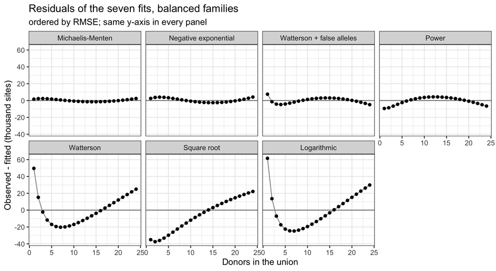

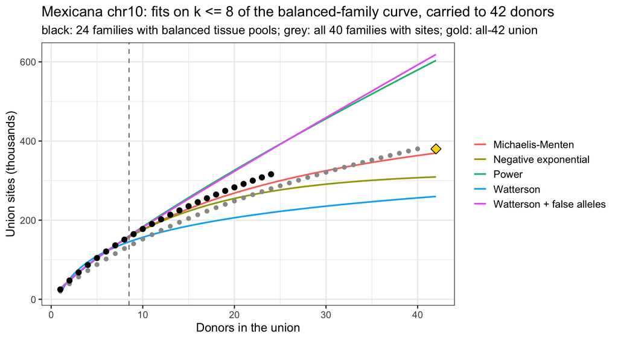

With the unbalanced families in (grey) the curve starts lower: they are the shallower donors, so a random set of $k$ holds fewer sites, and they add their sites late.

## Caveats

- Six donors, four races, all mexicana: every curve in section 3 fits them; the choice between curves rests on section 4, not on the fit. Discovery depth differs ninefold between them (9,060-85,952 tier-A sites), and two of the eight donors are off the curve.
- Zx.0500_P2 passes the sample introgression dosage check on its lines’ calls at union sites, but its own tier-A sites read a median 4.5 % ALT inside its lines’ REF segments, against 1-2 % for the other five (artifacts present in all lines), so some of its sites in the sharing patterns are likely false.
- The rarefaction mean averages over donors; a donor with few lines or low coverage finds fewer sites and adds fewer.
- Section 4’s numbers mix Chen’s discovery (individual genomes, 22x, strict filters) with ours (BC1 pools); $\eta$ and the $\varepsilon_f$ split are orders of magnitude.

## Appendix A: other accumulation curves, set aside

All fitted to the same six points (Eq. 4); the table and plot include the three curves of section 3.

| Model | $\bar U_n =$ | Spectrum it corresponds to | Why set aside |
| --- | --- | --- | --- |
| Logarithmic | $a + b \ln n$ | neutral, large $n$; Eq. 6 at $\alpha \to 0$ | the same as Watterson |
| Power | $a\, n^{b}$ | $p^{a' - 1}$, $-1 < a' < 0$, $b = -a'$; Eq. 6 at $\alpha < 0$ | $b$ = 0.74 needs $g(p) \propto p^{-1 - b}$, rapid population growth, which Chen’s MSMC2 history contradicts |
| Square root | $a \sqrt{n}$ | power with $b = 1/2$ | fixes the 6-to-1 donor ratio at 2.45, against 4.02 observed |
| Negative exponential | $U_\infty (1 - e^{-kn})$ | every site at one frequency; Eq. 6 at $\alpha \to \infty$ | no spread of frequencies |

| model | fitted parameters | RMSE (sites) | predicted at 10 donors |
| --- | --- | --- | --- |
| Michaelis-Menten | U_∞ = 474000, K = 9.39 | 328 | 244,577 |
| Watterson + false alleles | c = -18300, θ_η = 50700, ε_f = 13300 | 587 | 263,451 |
| Watterson | c = -55900, θ_η = 96100 | 4,710 | 225,400 |
| Logarithmic | a = 37600, b = 77500 | 7,038 | 216,032 |
| Power | a = 49800, b = 0.74 | 2,241 | 274,115 |
| Square root | a = 69900 | 13,615 | 220,927 |
| Negative exponential | U_∞ = 290000, K = 0.169 | 765 | 236,145 |

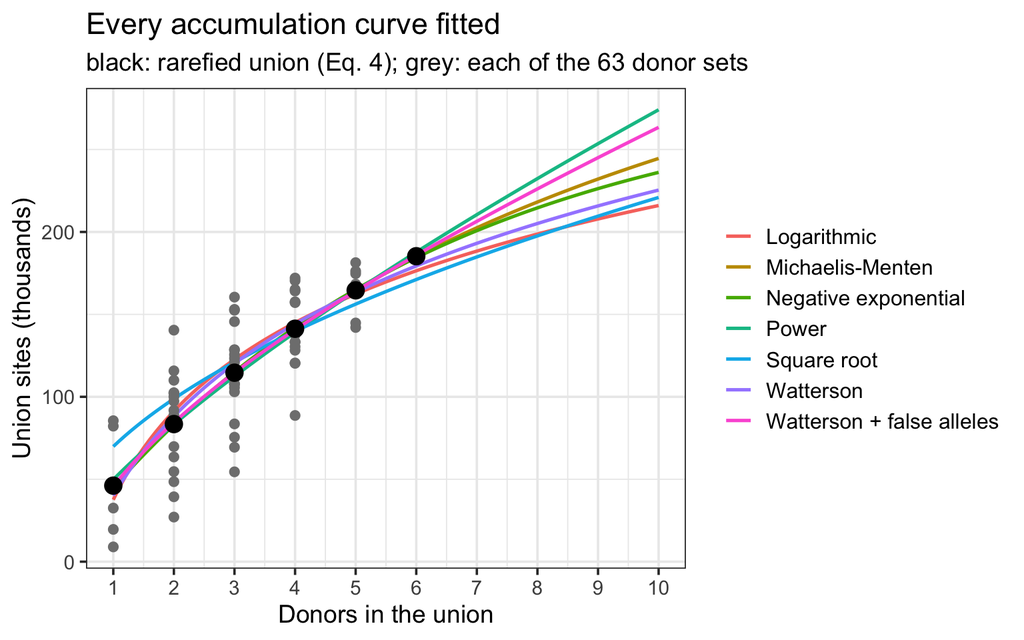

## Appendix B: pattern-level models, set aside

These fit the 15 sharing patterns of the four first-set donors (`union_rarefaction/patterns.tsv`, their own union of 170,729 sites) instead of the rarefied points, with a discovery sensitivity per donor. They are set aside because they have no false-allele or population-private class: the many private patterns (`0010`, `0001`) can only come from rare alleles and high $r_d$, so their parameters absorb errors and structure. They are the starting point for fitting S1-S3’s spectra to the patterns (a likelihood that allows AIC and likelihood-ratio tests, and per-donor predictions), once a private class is added.

### Version 2: a sensitivity per donor

$$g_2(p) = (1 - \phi)\, \frac{p^{a - 1}}{\sum_{q} q^{a - 1}} + \phi\, \mathbb{1}[p = 1], \qquad P(z) =
\sum_{p} g_2(p) \prod_{d = 1}^{4} (r_d\, p)^{z_d} (1 - r_d\, p)^{1 - z_d} \tag{B1}$$

$$\log L = \sum_{z \neq 0000} N_z \log \frac{P(z)}{1 - P(0000)}, \qquad \hat S =
U_{1234}^{\mathrm{obs}} / (1 - P(0000)) \tag{B2}$$

### Version 3: a shared class

A fraction $\phi$ of sites that every donor carries and finds with the same probability $e$ (the fixed differences $C$ of Eq. 1); the rest as B1 without the point mass ($g_3(p) \propto p^{a - 1}$):

$$P(z) = (1 - \phi) \sum_{p} g_3(p) \prod_{d = 1}^{4} (r_d\, p)^{z_d} (1 - r_d\, p)^{1 - z_d} \; + \;
\phi \prod_{d = 1}^{4} e^{z_d} (1 - e)^{1 - z_d} \tag{B3}$$

| version | r_0540 | r_0570 | r_0550 | r_0580 | a | phi | e | S | log_lik |
| --- | --- | --- | --- | --- | --- | --- | --- | --- | --- |
| 2 | 0.294 | 0.432 | 0.754 | 0.727 | 0.000 | 0.00 |  | 924,770 | -377,420.4 |
| 3 | 0.153 | 0.270 | 0.554 | 0.533 | 0.023 | 0.02 | 0.653 | 1,012,532 | -374,891.4 |

| pattern z | observed | Version 2 (B1) | Version 3 (B3) |
| --- | --- | --- | --- |
| 0010 | 44,999 | 39,953 | 43,884 |
| 0001 | 41,967 | 37,847 | 41,654 |
| 0100 | 17,982 | 19,530 | 18,706 |
| 0011 | 13,794 | 17,970 | 15,369 |
| 1000 | 9,998 | 12,646 | 10,313 |
| 0101 | 8,128 | 7,317 | 6,415 |
| 0111 | 5,887 | 6,967 | 5,043 |
| 1010 | 5,535 | 4,827 | 4,004 |
| 0110 | 5,366 | 7,856 | 6,757 |
| 1111 | 4,049 | 1,975 | 4,038 |
| 1011 | 3,590 | 4,116 | 3,516 |
| 1001 | 2,817 | 4,501 | 3,828 |
| 1110 | 2,424 | 1,646 | 2,537 |
| 1100 | 2,108 | 2,062 | 2,169 |
| 1101 | 2,085 | 1,514 | 2,498 |

Version 2 goes to the edge of B1 ($\phi \approx 0$, $a \approx 0$) and predicts about half of the sites found by all four donors (`1111`). Version 3 fits the patterns and the observed unions within 1 %, with a log-likelihood gain of 2529 for one more parameter.

## References

- Chen L, et al. 2022. Genome sequencing reveals evidence of adaptive variation in the genus *Zea*. *Nat Genet* 54:1736-1745 (main text and supplement: `agent/papers/chen2022/`).
- Sánchez González JJ, et al. 2018. Ecogeography of teosinte. *PLoS ONE* 13:e0192676.
- Soberón J, Llorente J. 1993. The use of species accumulation functions for the prediction of species richness. *Conserv Biol* 7:480-488.
- Watterson GA. 1975. On the number of segregating sites in genetical models without recombination. *Theor Popul Biol* 7:256-276.